# findings

### Change in Civil Rights

```python
cpr = pd.read_csv('./cpr.csv')
```

```python
cols_map = {
    # Political Freedom

    "polpart_*": "Right to participate in government",
    "assem_*": "Freedom of assembly and association",
    "express_*": "Right to opinion and expression",
    "union_*": "Right to form and join unions",
    "relig_*": "Freedom of religion and belief",

    # Civil Rights
    "tort_*": "Freedom from torture",
    "disap_*": "Freedom from disappearance",
    "exkill_*": "Freedom from extrajudicial execution",
    "arrest_*": "Freedom from arbitrary arrest or imprisonment",
    "dpex_*": "Freedom from death penalty"
}
```

```python
# extract and rename relevant columns to civil rights

civil_rights_mean_columns = [
    'country',
    'year',
    "tort_mean",
    "disap_mean",
    "exkill_mean",
    "arrest_mean",
    "dpex_mean"
]

cr_map = {
    "tort_mean": "Freedom from torture",
    "disap_mean": "Freedom from disappearance",
    "exkill_mean": "Freedom from extrajudicial execution",
    "arrest_mean": "Freedom from arbitrary arrest or imprisonment",
    "dpex_mean": "Freedom from death penalty"
}

df = cpr.copy()
df = df[civil_rights_mean_columns]

df = df.rename(columns=cr_map)

df.head()
```

|  | country | year | Freedom from torture | Freedom from disappearance | Freedom from extrajudicial execution | Freedom from arbitrary arrest or imprisonment | Freedom from death penalty |
| --- | --- | --- | --- | --- | --- | --- | --- |
| 0 | Angola | 2017 | 3.439210 | 6.464161 | 5.088942 | 3.789929 | 10.0 |
| 1 | Angola | 2018 | 4.458768 | 7.174069 | 5.283046 | 4.850208 | 10.0 |
| 2 | Angola | 2019 | 4.902350 | 6.357960 | 5.029688 | 4.970274 | 10.0 |
| 3 | Angola | 2020 | 4.754113 | 5.453531 | 3.844958 | 4.245430 | 10.0 |
| 4 | Angola | 2021 | 3.600660 | 4.963902 | 4.165898 | 3.885606 | 10.0 |

```python
# Take the mean values for each year to understand changes overtime
df_yearly_mean = df.groupby('year').mean(numeric_only=True)
df_yearly_mean.head()
```

| year | Freedom from torture | Freedom from disappearance | Freedom from extrajudicial execution | Freedom from arbitrary arrest or imprisonment | Freedom from death penalty |
| --- | --- | --- | --- | --- | --- |
| 2017 | 4.887877 | 6.819960 | 6.294702 | 5.258171 | 9.271419 |
| 2018 | 5.505195 | 7.320203 | 6.739419 | 5.687271 | 9.458731 |
| 2019 | 5.887445 | 7.631489 | 7.017165 | 5.946407 | 9.546117 |
| 2020 | 5.808151 | 7.426848 | 7.087485 | 6.211538 | 9.274424 |
| 2021 | 5.866108 | 7.267479 | 7.119212 | 6.169052 | 9.276985 |

#### Change Graphed

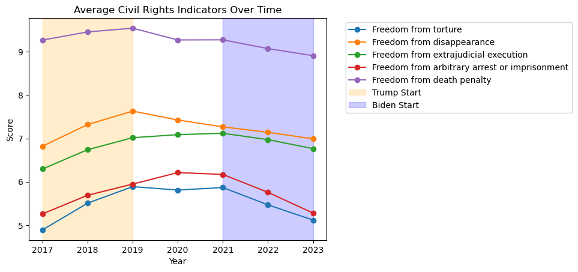

```python
from collections import OrderedDict

ax = df_yearly_mean.plot(marker='o')
plt.title('Average Civil Rights Indicators Over Time')
plt.xlabel('Year')
plt.ylabel('Score')
plt.legend(title='Indicator', bbox_to_anchor=(1.05, 1), loc='upper left')

# Shade 2017-2018 (Trump start) and 2021-2022 (Biden start)
plt.axvspan(2017, 2019, color='orange', alpha=0.2, label='Trump Start')
plt.axvspan(2021, 2023, color='blue', alpha=0.2, label='Biden Start')

handles, labels = ax.get_legend_handles_labels()
by_label = OrderedDict(zip(labels, handles))
plt.legend(by_label.values(), by_label.keys(), bbox_to_anchor=(1.05, 1), loc='upper left')
plt.show()
```

Based on this plot, it seems as though the average civil rights over time is following a light cyclical pattern. All of the indicators increased at the start of the Trump presidency, remained relatively constant throughout the remainder of his term, and then decreased at the start of the Biden presidency. Unlike the Political Freedom analysis, however, the indicators remained very similar over time and did not see huge shifts throughout the period.